# Intro to Quasi-experiments

Juan Gelvez-Ferreira, Ph.D. Student

2023-11-08

## Brief introduction to quasi-experiments

**Regression Discontinuity Design**

### Real example: ADA

The Americans for Democratic Action (ADA) score is a voting record index. For each Congress, the ADA chose high-profile roll-call votes and created an index varying from 0 to 100 for each representative elected between 1946–1995. Higher scores correspond to a more “liberal” voting record.

The running variable in this study is the vote share. That is the share of all votes that went to a Democrat.

```r
library(tidyverse)
library(haven)
library(estimatr)
library(skimr)

read_data <- function(df)
{
  full_path <- paste("https://github.com/scunning1975/mixtape/raw/master/",
                     df, sep = "")
  df <- read_dta(full_path)
  return(df)
}

lmb_data <- read_data("lmb-data.dta")
```

- Dependent Variable: Score
- Cutoff: Democrats’ vote share.

```r
lmb_subset <- lmb_data %>%
  filter(lagdemvoteshare>.48 & lagdemvoteshare<.52)

lm_1 <- lm_robust(score ~ lagdemocrat, data = lmb_subset, clusters = id)
lm_2 <- lm_robust(score ~ democrat, data = lmb_subset, clusters = id)

summary(lm_1)
```

```
##
## Call:
## lm_robust(formula = score ~ lagdemocrat, data = lmb_subset, clusters = id)
##
## Standard error type:  CR2
##
## Coefficients:
##             Estimate Std. Error t value  Pr(>|t|) CI Lower CI Upper    DF
## (Intercept)    31.20      1.334   23.39 5.880e-80    28.57    33.82 454.0
## lagdemocrat    21.28      1.951   10.91 3.988e-26    17.45    25.11 912.9
##
## Multiple R-squared:  0.1152 ,    Adjusted R-squared:  0.1142
## F-statistic:   119 on 1 and 914 DF,  p-value: < 2.2e-16
```

```r
summary(lm_2)
```

```
##
## Call:
## lm_robust(formula = score ~ democrat, data = lmb_subset, clusters = id)
##
## Standard error type:  CR2
##
## Coefficients:
##             Estimate Std. Error t value   Pr(>|t|) CI Lower CI Upper    DF
## (Intercept)    18.75     0.8432   22.23  2.313e-75    17.09    20.40 470.0
## democrat       47.71     1.3560   35.18 7.434e-172    45.04    50.37 909.8
##
## Multiple R-squared:  0.5783 ,    Adjusted R-squared:  0.5779
## F-statistic:  1238 on 1 and 914 DF,  p-value: < 2.2e-16
```

Notice the window we are only using observations between 0.48 and 0.52 vote share. So this regression is estimating the coefficient on right around the cutoff. What happens if we use all the data?

```r
#using all data (note data used is lmb_data, not lmb_subset)

lm_1 <- lm_robust(score ~ lagdemocrat, data = lmb_data, clusters = id)
lm_2 <- lm_robust(score ~ democrat, data = lmb_data, clusters = id)

summary(lm_1)
```

```
##
## Call:
## lm_robust(formula = score ~ lagdemocrat, data = lmb_data, clusters = id)
##
## Standard error type:  CR2
##
## Coefficients:
##             Estimate Std. Error t value Pr(>|t|) CI Lower CI Upper    DF
## (Intercept)    23.54     0.3375   69.75        0    22.88    24.20  5669
## lagdemocrat    31.51     0.4837   65.14        0    30.56    32.45 12211
##
## Multiple R-squared:  0.2267 ,    Adjusted R-squared:  0.2267
## F-statistic:  4243 on 1 and 13587 DF,  p-value: < 2.2e-16
```

```r
summary(lm_2)
```

```
##
## Call:
## lm_robust(formula = score ~ democrat, data = lmb_data, clusters = id)
##
## Standard error type:  CR2
##
## Coefficients:
##             Estimate Std. Error t value Pr(>|t|) CI Lower CI Upper    DF
## (Intercept)    17.58     0.2626   66.94        0    17.06    18.09  5479
## democrat       40.76     0.4182   97.48        0    39.94    41.58 11758
##
## Multiple R-squared:  0.3756 ,    Adjusted R-squared:  0.3755
## F-statistic:  9502 on 1 and 13587 DF,  p-value: < 2.2e-16
```

Simply running the regression yields different estimates when we include data far from the cutoff itself.

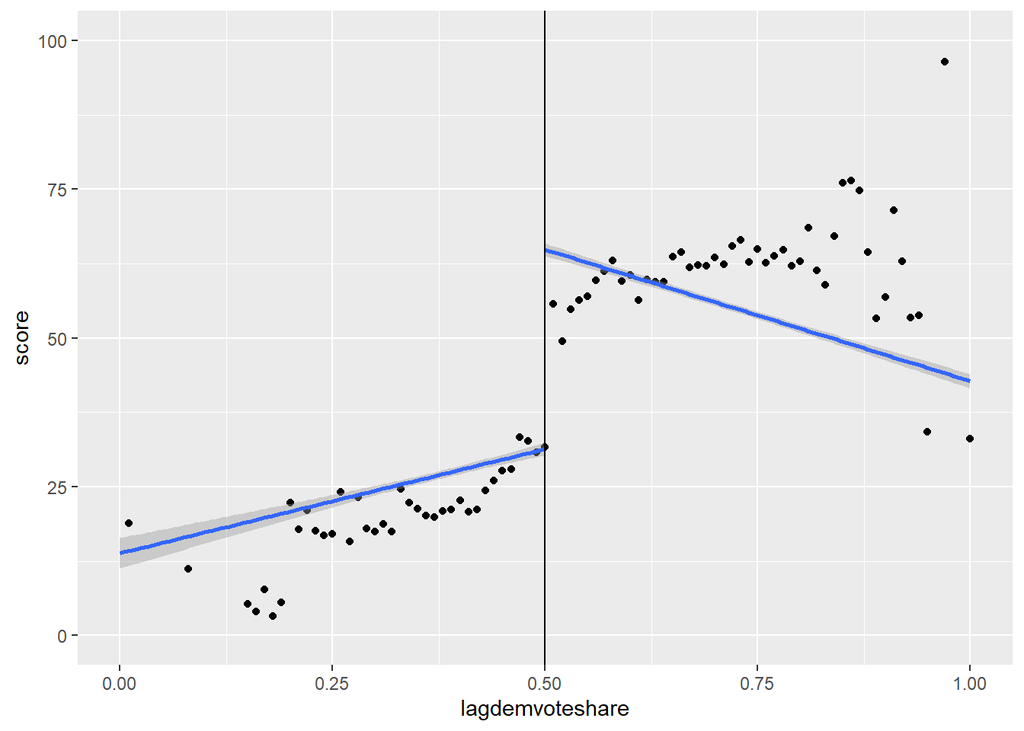

```r
#aggregating the data
categories <- lmb_data$lagdemvoteshare

demmeans <- split(lmb_data$score, cut(lmb_data$lagdemvoteshare, 100)) %>%
  lapply(mean) %>%
  unlist()

agg_lmb_data <- data.frame(score = demmeans, lagdemvoteshare = seq(0.01,1, by = 0.01))

#plotting
lmb_data <- lmb_data %>%
  mutate(gg_group = case_when(lagdemvoteshare > 0.5 ~ 1, TRUE ~ 0))

ggplot(lmb_data, aes(lagdemvoteshare, score)) +
  geom_point(aes(x = lagdemvoteshare, y = score), data = agg_lmb_data) +
  stat_smooth(aes(lagdemvoteshare, score, group = gg_group), method = "lm") +
  xlim(0,1) + ylim(0,100) +
  geom_vline(xintercept = 0.5)
```

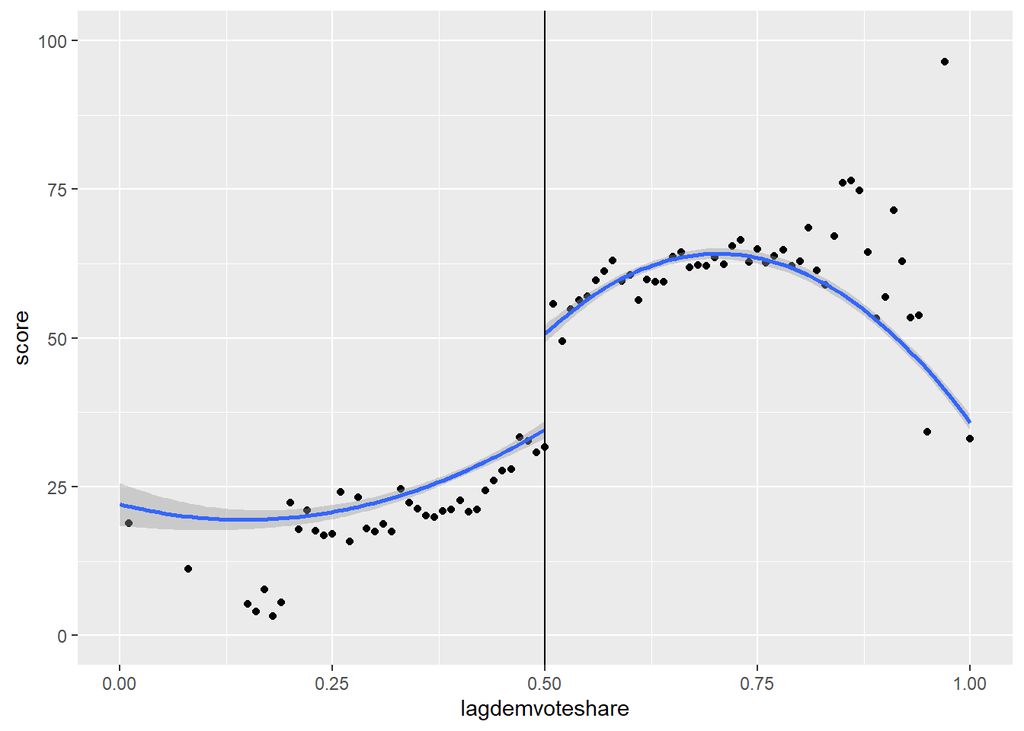

```r
ggplot(lmb_data, aes(lagdemvoteshare, score)) +
  geom_point(aes(x = lagdemvoteshare, y = score), data = agg_lmb_data) +
  stat_smooth(aes(lagdemvoteshare, score, group = gg_group), method = "lm",
              formula = y ~ x + I(x^2)) +
  xlim(0,1) + ylim(0,100) +
  geom_vline(xintercept = 0.5)
```

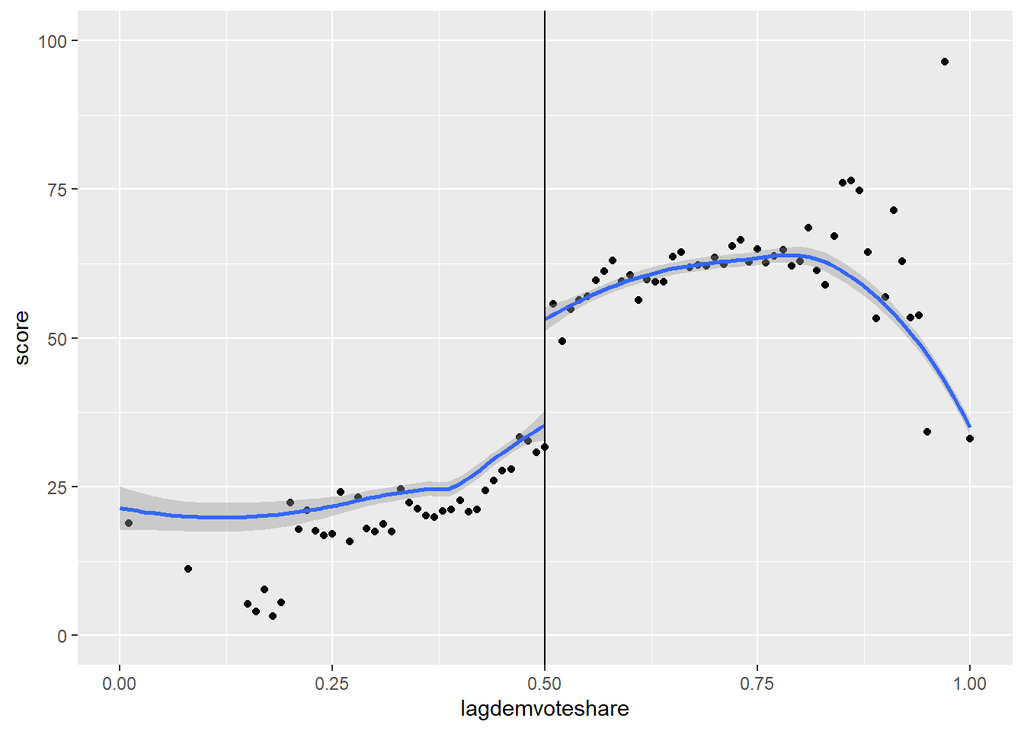

```r
ggplot(lmb_data, aes(lagdemvoteshare, score)) +
  geom_point(aes(x = lagdemvoteshare, y = score), data = agg_lmb_data) +
  stat_smooth(aes(lagdemvoteshare, score, group = gg_group), method = "loess") +
  xlim(0,1) + ylim(0,100) +
  geom_vline(xintercept = 0.5)
```

Finally, bandwidth selection, or window, for estimating the causal effect using this method is key. Recent work has been focused on optimal bandwidth selection.

In RStudio, you can implemented it with the rdrobust command. These methods choose optimal bandwidths that may differ left and right of the cutoff based on some bias-variance trade-off.

```r
library(tidyverse)
library(rdrobust)

rdr <- rdrobust(y = lmb_data$score,
                x = lmb_data$demvoteshare, c = 0.5)
```

```
## [1] "Mass points detected in the running variable."
```

```r
summary(rdr)
```

```
## Sharp RD estimates using local polynomial regression.
##
## Number of Obs.                13577
## BW type                       mserd
## Kernel                   Triangular
## VCE method                       NN
##
## Number of Obs.                 5480         8097
## Eff. Number of Obs.            2112         1893
## Order est. (p)                    1            1
## Order bias  (q)                   2            2
## BW est. (h)                   0.086        0.086
## BW bias (b)                   0.141        0.141
## rho (h/b)                     0.609        0.609
## Unique Obs.                    2770         3351
##
## =============================================================================
##         Method     Coef. Std. Err.         z     P>|z|      [ 95% C.I. ]
## =============================================================================
##   Conventional    46.491     1.241    37.477     0.000    [44.060 , 48.923]
##         Robust         -         -    31.425     0.000    [43.293 , 49.052]
## =============================================================================
```

- This example was taken from Lee, Moretti, and Butler (2004), and Cunningham (2021)

Cunningham, Scott. Causal inference: The mixtape. Yale university press, 2021. Lee, David S., Enrico Moretti, and Matthew J. Butler. 2004. “Do Voters Affect or Elect Policies: Evidence from the u.s. House.” Quarterly Journal of Economics 119 (3): 807–59.